# Matlab FF_OPTIM_BISEC_SAVEZRONE Optimal Savings Share Concurrent Bisection

[Fan Wang](https://fanwangecon.github.io/)

2020-07-02

# 1 faFF_OPTIM_BISEC_SAVEZRONE Derivative Bisection

> Go to the [**MLX**](https://github.com/FanWangEcon//MEconTools/blob/master/G:/repos/MEconTools/MEconTools/doc/optim//fx_optim_bisec_savezrone.mlx), [**M**](https://github.com/FanWangEcon//MEconTools/blob/master/G:/repos/MEconTools/MEconTools/doc/optim//htmlpdfm/fx_optim_bisec_savezrone.m), [**PDF**](https://github.com/FanWangEcon//MEconTools/blob/master/G:/repos/MEconTools/MEconTools/doc/optim//htmlpdfm/fx_optim_bisec_savezrone.pdf), or [**HTML**](https://fanwangecon.github.io//MEconTools/G:/repos/MEconTools/MEconTools/doc/optim//htmlpdfm/fx_optim_bisec_savezrone.html) version of this file. Go back to [fan](http://fanwangecon.github.io/)’s [MEconTools](https://fanwangecon.github.io/MEconTools/) Toolbox (bookdown), [Matlab Code Examples](https://fanwangecon.github.io/MEconTools/) Repository (bookdown), or [Math for Econ with Matlab](https://fanwangecon.github.io/Math4Econ/) Repository (bookdown).

The vectorized and looped bisection savings problem rely on this function to solve for optimal savings choices:

- States Grid + Continuous Exact Savings as Share of Cash-on-Hand *Loop*:[**ff_vfi_az_bisec_loop**](https://github.com/FanWangEcon/MEconTools/blob/master/MEconTools/vfi/ff_vfi_az_bisec_loop.m), high precision even with small grid
- States Grid + Continuous Exact Savings as Share of Cash-on-Hand *Vectorized*: [**ff_vfi_az_bisec_vec**](https://github.com/FanWangEcon/MEconTools/blob/master/MEconTools/vfi/ff_vfi_az_bisec_vec.m), precision and speed

## 1.1 Test FF_OPTIM_BISEC_SAVEZRONE Defaults

Call the function with defaults, this solves concurrently for many state-space points’ optimization problems:

```
ff_optim_bisec_savezrone();

Elapsed time is 0.105423 seconds.
BISECT END: iteration=16, norm(ar_mid_fx)=0.00030653
                                 vartype    paramgroup2    paramgroup3    paramgroup4    paramgroup5    paramgroup6    paramgroup7    paramgroup8    paramgroup9
                                 _______    ___________    ___________    ___________    ___________    ___________    ___________    ___________    ___________

    a                            "init"           1e-05          1e-05          1e-05          1e-05          1e-05          1e-05          1e-05          1e-05
    b                            "init"         0.99999        0.99999        0.99999        0.99999        0.99999        0.99999        0.99999        0.99999
    f_a                          "init"           33802          40925          67047          15411          63263     1.9839e+05          25282          70686
    f_b                          "init"          -46789    -1.2672e+05    -1.8532e+05         -67518         -48900    -1.2164e+05         -23149         -49303
    it1_fp                       "fatx"        -0.25973        -1.7159        -2.3655        -1.0421        0.28726          1.535       0.042644        0.42766
    it1_p                        "x"                0.5            0.5            0.5            0.5            0.5            0.5            0.5            0.5
    it2_fp                       "fatx"         0.72822      -0.052631        0.21087       -0.28379        -1.1125        -2.2202       -0.58887        -1.0296
    it2_p                        "x"               0.25           0.25           0.25           0.25        0.74999        0.74999        0.74999        0.74999
    it3_fp                       "fatx"         0.15277         1.8256        -1.1773        0.46124       -0.29179      -0.069428       -0.21281       -0.18376
    it3_p                        "x"              0.375        0.12501          0.375        0.12501          0.625          0.625          0.625          0.625
    it4_fp                       "fatx"       -0.059183        0.62299       -0.55013     -0.0090579      0.0069602        0.74664      -0.079677        0.12972
    it4_p                        "x"             0.4375        0.18751         0.3125        0.18751         0.5625         0.5625         0.5625         0.5625
    it5_fp                       "fatx"        0.044028         0.2488       -0.19454         0.1861       -0.13821        0.34715      -0.017964      -0.023106
    it5_p                        "x"            0.40625        0.21876        0.28125        0.15626        0.59375        0.59375        0.53125        0.59375
    it6_fp                       "fatx"      -0.0080863       0.090981     0.00054305       0.081339      -0.064832        0.14171       0.012387       0.054017
    it6_p                        "x"            0.42188        0.23438        0.26563        0.17188        0.57812        0.60937        0.51562        0.57812
    it7_fp                       "fatx"        0.017822       0.017593      -0.098707       0.034591      -0.028768       0.036948     -0.0027658       0.015665
    it7_p                        "x"            0.41406        0.24219        0.27344        0.17969        0.57031        0.61719        0.52344        0.58594
    it8_fp                       "fatx"       0.0048335      -0.017893      -0.049532       0.012405      -0.010865      -0.016025      0.0048149      -0.003664
    it8_p                        "x"            0.41797         0.2461        0.26954         0.1836         0.5664        0.62109        0.51953        0.58984
    it9_fp                       "fatx"      -0.0016347    -0.00024633       -0.02461      0.0015865     -0.0019434       0.010514      0.0010259      0.0060142
    it9_p                        "x"            0.41992        0.24415        0.26758        0.18555        0.56445        0.61914        0.52148        0.58789
    it10_fp                      "fatx"       0.0015973      0.0086488      -0.012063     -0.0037571      0.0025106     -0.0027422    -0.00086962      0.0011786
```

[output cut: 16 more lines]

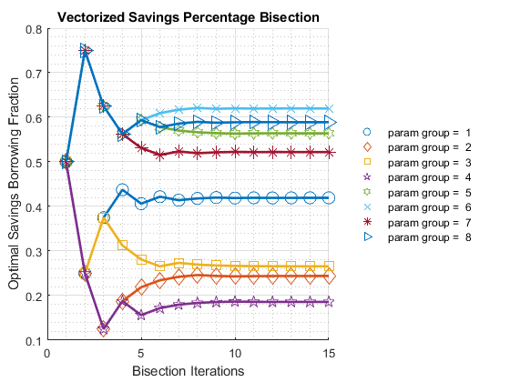

```
----------------------------------------
xxxxxxxxxxxxxxxxxxxxxxxxxxxxxxxxxxxxxxxx
CONTAINER NAME: mp_container_map ND Array (Matrix etc)
xxxxxxxxxxxxxxxxxxxxxxxxxxxxxxxxxxxxxxxx
                         i    idx    ndim    numel    rowN    colN       sum           mean          std        coefvari        min           max
                         _    ___    ____    _____    ____    ____    __________    __________    __________    ________    ___________    __________

    ar_opti_foc_obj      1     1      2        8       1       8      0.00050535    6.3168e-05    9.4141e-05     1.4903     -0.00013343    0.00015981
    ar_opti_save_frac    2     2      2        8       1       8            3.41       0.42626       0.17279    0.40536         0.18583        0.6199

xxx TABLE:ar_opti_foc_obj xxxxxxxxxxxxxxxxxx
              c1            c2            c3            c4            c5             c6            c7            c8
          __________    __________    __________    __________    ___________    __________    __________    __________

    r1    8.1766e-05    3.0909e-05    0.00014822    7.9241e-05    -0.00013343    0.00015981    1.8966e-05    0.00011986

xxx TABLE:ar_opti_save_frac xxxxxxxxxxxxxxxxxx
            c1        c2         c3         c4         c5         c6       c7        c8
          ______    _______    _______    _______    _______    ______    _____    _______

    r1    0.4194    0.24412    0.26566    0.18583    0.56406    0.6199    0.522    0.58908
```

## 1.2 Test FF_OPTIM_BISEC_SAVEZRONE One Individual

Bisection for savings choice at one state:

```
% Generate the state-space and function
[fl_z1, fl_z2, fl_r, fl_beta] = deal(0.4730, 0.6252, 0.0839, 0.7365);
% ffi_intertemporal_max is a function in ff_optim_bisec_savezrone for testing
fc_deri_wth_uniroot = @(x) ffi_intertemporal_max(x, fl_z1, fl_z2, fl_r, fl_beta);
% Call Function
bl_verbose = true;
ff_optim_bisec_savezrone(fc_deri_wth_uniroot, bl_verbose);

BISECT END: iteration=16, norm(ar_mid_fx)=0.00016724
                  vartype    paramgroup2
                  _______    ___________

    a             "init"           1e-05
    b             "init"         0.99999
    f_a           "init"           70155
    f_b           "init"          -95255
    it1_fp        "fatx"          -0.502
    it1_p         "x"                0.5
    it2_fp        "fatx"          1.5361
    it2_p         "x"               0.25
    it3_fp        "fatx"         0.34671
    it3_p         "x"              0.375
    it4_fp        "fatx"       -0.089881
    it4_p         "x"             0.4375
    it5_fp        "fatx"         0.12259
    it5_p         "x"            0.40625
    it6_fp        "fatx"        0.015276
    it6_p         "x"            0.42188
    it7_fp        "fatx"       -0.037529
    it7_p         "x"            0.42969
    it8_fp        "fatx"       -0.011188
    it8_p         "x"            0.42578
    it9_fp        "fatx"       0.0020277
    it9_p         "x"            0.42383
    it10_fp       "fatx"      -0.0045843
    it10_p        "x"            0.42481
    it11_fp       "fatx"      -0.0012793
    it11_p        "x"            0.42432
    it12_fp       "fatx"      0.00037392
    it12_p        "x"            0.42407
    it13_fp       "fatx"     -0.00045276
    it13_p        "x"             0.4242
    it14_fp       "fatx"     -3.9436e-05
    it14_p        "x"            0.42413
    it15_fp       "fatx"      0.00016724
    it15_p        "x"             0.4241
    it15_level    "level"       -0.13158
```

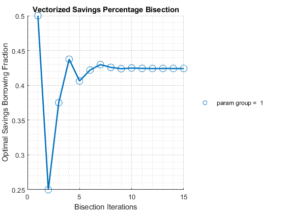

```
----------------------------------------
xxxxxxxxxxxxxxxxxxxxxxxxxxxxxxxxxxxxxxxx
CONTAINER NAME: mp_container_map Scalars
xxxxxxxxxxxxxxxxxxxxxxxxxxxxxxxxxxxxxxxx
                         i    idx      value
                         _    ___    __________

    ar_opti_foc_obj      1     1     0.00016724
    ar_opti_save_frac    2     2         0.4241
```

```
% Generate the state-space and function
ar_z1 = [1,2,3]';
ar_z2 = [3,2,1]';
ar_r = [1.05, 1.50, 1.30]';
ar_beta = [0.80, 0.95, 1.50]';
mt_fc_inputs = [ar_z1, ar_z2, ar_r, ar_beta];
% ffi_intertemporal_max is a function in ff_optim_bisec_savezrone for testing
fc_deri_wth_uniroot = @(x) ffi_intertemporal_max(x, ar_z1, ar_z2, ar_r, ar_beta);
% Call Function
bl_verbose = true;
ff_optim_bisec_savezrone(fc_deri_wth_uniroot, bl_verbose);

BISECT END: iteration=16, norm(ar_mid_fx)=8.9847e-05
                  vartype    paramgroup2    paramgroup3    paramgroup4
                  _______    ___________    ___________    ___________

    a             "init"           1e-05          1e-05          1e-05
    b             "init"         0.99999        0.99999        0.99999
    f_a           "init"           32475          33928          43671
    f_b           "init"          -40594         -35714         -29113
    it1_fp        "fatx"        -0.16238      -0.035714        0.29114
    it1_p         "x"                0.5            0.5            0.5
    it2_fp        "fatx"         0.75773        0.88092       -0.58225
    it2_p         "x"               0.25           0.25        0.74999
    it3_fp        "fatx"         0.21649        0.33333      -0.077629
    it3_p         "x"              0.375          0.375          0.625
    it4_fp        "fatx"        0.020615        0.14059        0.11091
    it4_p         "x"             0.4375         0.4375         0.5625
    it5_fp        "fatx"        -0.07132       0.051539       0.018865
    it5_p         "x"            0.46875        0.46875        0.59375
    it6_fp        "fatx"       -0.025599      0.0078193      -0.028659
    it6_p         "x"            0.45313        0.48438        0.60937
    it7_fp        "fatx"      -0.0025711      -0.013955     -0.0047386
    it7_p         "x"            0.44531        0.49219        0.60156
    it8_fp        "fatx"       0.0090001     -0.0030715      0.0071001
    it8_p         "x"            0.44141        0.48828        0.59765
    it9_fp        "fatx"       0.0032093      0.0023727      0.0011903
    it9_p         "x"            0.44336        0.48633        0.59961
    it10_fp       "fatx"      0.00031783    -0.00034971     -0.0017717
    it10_p        "x"            0.44434         0.4873        0.60058
    it11_fp       "fatx"      -0.0011269      0.0010114    -0.00029011
    it11_p        "x"            0.44483        0.48682         0.6001
    it12_fp       "fatx"     -0.00040464     0.00033083     0.00045024
    it12_p        "x"            0.44458        0.48706        0.59985
    it13_fp       "fatx"     -4.3425e-05    -9.4396e-06     8.0103e-05
    it13_p        "x"            0.44446        0.48718        0.59997
    it14_fp       "fatx"       0.0001372      0.0001607      -0.000105
    it14_p        "x"             0.4444        0.48712        0.60003
    it15_fp       "fatx"      4.6884e-05     7.5628e-05    -1.2444e-05
    it15_p        "x"            0.44443        0.48715            0.6
    it15_level    "level"        -0.3686        0.56403         1.6261
```

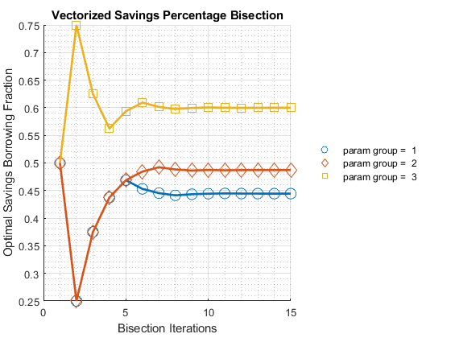

```
----------------------------------------
xxxxxxxxxxxxxxxxxxxxxxxxxxxxxxxxxxxxxxxx
CONTAINER NAME: mp_container_map ND Array (Matrix etc)
xxxxxxxxxxxxxxxxxxxxxxxxxxxxxxxxxxxxxxxx
                         i    idx    ndim    numel    rowN    colN       sum           mean          std        coefvari        min           max
                         _    ___    ____    _____    ____    ____    __________    __________    __________    ________    ___________    __________

    ar_opti_foc_obj      1     1      2        3       1       3      0.00011007    3.6689e-05    4.4913e-05     1.2241     -1.2444e-05    7.5628e-05
    ar_opti_save_frac    2     2      2        3       1       3          1.5316       0.51053      0.080379    0.15744         0.44443           0.6

xxx TABLE:ar_opti_foc_obj xxxxxxxxxxxxxxxxxx
              c1            c2            c3
          __________    __________    ___________

    r1    4.6884e-05    7.5628e-05    -1.2444e-05

xxx TABLE:ar_opti_save_frac xxxxxxxxxxxxxxxxxx
            c1         c2       c3
          _______    _______    ___

    r1    0.44443    0.48715    0.6
```

## 1.4 Test FF_OPTIM_BISEC_SAVEZRONE Speed

Test Speed doing 6.25 million bisections for a savings problem:

```
% Generate the state-space and function
rng(123);
it_draws = 6250000; % must be even number
ar_z1 = exp(rand([it_draws,1])*3-1.5);
ar_z2 = exp(rand([it_draws,1])*3-1.5);
ar_r = (rand(it_draws,1)*10.0);
ar_beta = [rand(round(it_draws/2),1)*0.9+0.1; rand(round(it_draws/2),1)*0.9+1];
% ffi_intertemporal_max is a function in ff_optim_bisec_savezrone for testing
fc_deri_wth_uniroot = @(x) ffi_intertemporal_max(x, ar_z1, ar_z2, ar_r, ar_beta);
% Call Function
bl_verbose = false;
bl_timer = true;
[ar_opti_save_frac, ar_opti_save_level] = ff_optim_bisec_savezrone(fc_deri_wth_uniroot, bl_verbose, bl_timer);

Elapsed time is 2.570982 seconds.

mp_container_map = containers.Map('KeyType','char', 'ValueType','any');
mp_container_map('ar_opti_save_frac') = ar_opti_save_frac;
mp_container_map('ar_opti_save_level') = ar_opti_save_level;
mp_container_map('ar_opti_save_frac_notnan') = ar_opti_save_frac(~isnan(ar_opti_save_frac));
ff_container_map_display(mp_container_map);

----------------------------------------
xxxxxxxxxxxxxxxxxxxxxxxxxxxxxxxxxxxxxxxx
CONTAINER NAME: mp_container_map ND Array (Matrix etc)
xxxxxxxxxxxxxxxxxxxxxxxxxxxxxxxxxxxxxxxx
                                i    idx    ndim     numel        rowN      colN       sum         mean        std      coefvari      min        max
                                _    ___    ____    ________    ________    ____    __________    _______    _______    ________    _______    _______

    ar_opti_save_frac           1     1      2      6.25e+06    6.25e+06     1       2.884e+06    0.46144    0.15306    0.33171     0.09092    0.65518
    ar_opti_save_frac_notnan    2     2      2      6.25e+06    6.25e+06     1       2.884e+06    0.46144    0.15306    0.33171     0.09092    0.65518
    ar_opti_save_level          3     3      2      6.25e+06    6.25e+06     1      2.9482e+06    0.47172    0.66667     1.4133     -3.9805     2.9221

figure();
histogram(ar_opti_save_frac(~isnan(ar_opti_save_frac)),100);
title('Distribution of Optimal Savings Fractions');
xlabel('Savings Fractions');
grid on;
```

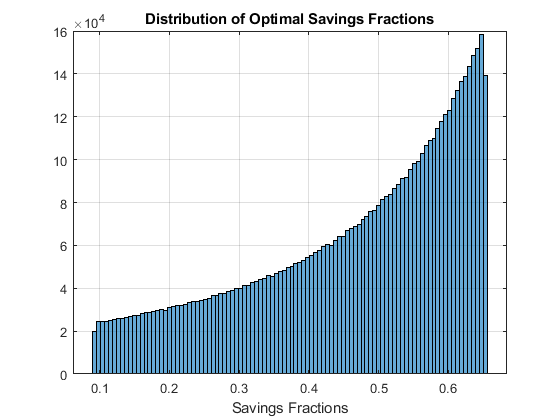

## 1.5 Define Two Period Intertemporal FOC Log Utility No Shock

See [Household’s Utility Maximization Problem and Two-Period Borrowing and Savings Problem given Endowments](https://fanwangecon.github.io/Math4Econ/derivative_application/htmlpdfm/K_save_households.html).

```
function [ar_deri_zero, ar_saveborr_level] = ffi_intertemporal_max(ar_saveborr_frac, z1, z2, r, beta)
    ar_saveborr_level = ar_saveborr_frac.*(z1+z2./(1+r)) - z2./(1+r);
    ar_deri_zero = 1./(ar_saveborr_level-z1) + (beta.*(r+1))./(z2 + ar_saveborr_level.*(r+1));
end
```